# FMDB Size Structure Walk-Through

# Summary Statistics and Graphics

### Simple Summaries

Frequencies of individuals are created with `xtabs()` which takes a formula of the form `~rows` or `~rows+cols`, where `rows` and `cols` generically represent the variables to form the rows and columns, respectively, of the frequency table. The data.frame that contains the `rows` and `cols` variables must be given in `data=`.

```r
> xtabs(~Species1,data=SprLC)
Species1
  Black Crappie        Bluegill          Bowfin Largemouth Bass   Northern Pike     Pumpkinseed
           3619             589              10             274              40              36
      Rock Bass Smallmouth Bass         Walleye    Yellow Perch
              2              10              72            2222
```

```r
> xtabs(~Mon+Waterbody.Name,data=BGSpr)
     Waterbody.Name
Mon   BLACK DAN LAKE CONNORS LAKE DURPHEE LAKE GREEN LAKE LAKE CHETAC LAKE CHIPPEWA
  May            599           90          603          0         589           746
  Jun              0          108            0        144           0             0
     Waterbody.Name
Mon   LAKE OF THE PINES LOWER CLAM LAKE MOOSE LAKE ROUND LAKE WHITEFISH LAKE
  May               213              35          1        414             72
  Jun                90               0          0          0              0
```

Summary statistics for a quantitative variable are efficiently computed with `Summarize()` from the `FSA` package (note the capital S). This function takes a formula of the form `~quant`, where `quant` generically represents the name of a quantitative variable, as the first argument and the data.frame that contains that variable in `data=`. The number of decimals for the returned statistics is optionally controlled with `digits=`. The code below summarizes the lengths of Bluegill captured in Spring samples from Lake Chetac.

```r
> Summarize(~Len,data=BGSprLC,digits=2)
       n   nvalid     mean       sd      min       Q1   median       Q3      max percZero
  398.00   398.00     5.98     1.16     3.00     5.00     6.20     6.90     8.90     0.00
```

A histogram of a quantitative variable is constructed with `hist()` from the `FSA` package. The first two arguments to `hist()` are exactly the same as the first two arguments to `Summarize()`. The cutoffs for the bins on the histogram may be defined with `breaks=`. For fisheries purposes, the cutoffs are usually evenly spaced and, thus, can be easily constructed as a sequence of values. A simple sequence of values is constructed with `seq()` with the starting values as the first argument, the ending value as the last argument, and the step width between those two values as the last argument. For example, the code in the `breaks=` below constructs a sequence of numbers that starts with 3, end with 9, with steps of 0.2 (i.e., 3, 3.2, 3.4, etc.). The x and y axes are labeled with string in `xlab=` and `ylab=`, respectively. The numerical limits of the x and y axes are controlled by including a vector of two values that represent the minimum and maximum values for the axes in `xlim=` and `ylim=`, respectively.

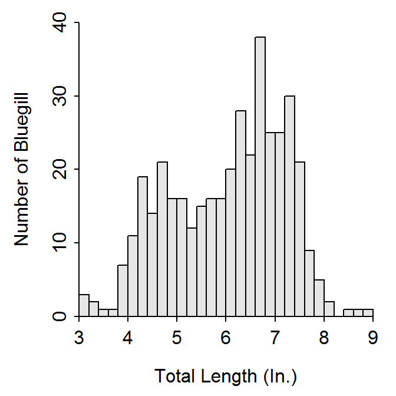

```r
> hist(~Len,data=BGSprLC,breaks=seq(3,9,0.2),
       xlab="Total Length (In.)",ylab="Number of Bluegill",
       xlim=c(3,9),ylim=c(0,40))
```

### Multiple Summaries

Numerical summaries can be efficiently computed for multiple groups using a combination of `group_by()` and `summarize()` (note the lower-case s) from the `dplyr` package. The `group_by` function creates groups for the data.frame given in it first argument based on the groups given in its ensuing arguments. The `group_by()` function below will create groups based on `Waterbody.Name` (i.e., by lakes or rivers) for the `BGSpr` data.frame (which is “piped” into the first argument of `group_by()` with `%>%`). The `summarize()` function then creates summaries defined by the user for each group. A wide variety of summaries can be defined, but the example below uses `n()` to count the number of individuals (i.e., sample size), `mean()` to compute an average, `sd()` to compute a standard deviation, and `min()` and `max()` to compute the minimum and maximum values. The `n()` function does not require any arguments, whereas the other functions require the name of a quantitative variable as the first argument. Also note that these functions use `na.rm=TRUE` to remove missing values from the variable (otherwise, for example, a mean will not be computed). Note that the `sum(!is.na(Len))` code is a “trick” used to count the number non-missing values in the variable (a “valid” sample size). The result from `summarize()` is “piped” into `as.data.frame()` to remove the grouping structure (which is not needed after the summarization) and other attributes that were added to the result. Thus, the code below computes the sample size, valid sample size, and mean, standard deviation, minimum, and maximum lengths of Bluegill in all water bodies sampled in the spring.

```r
> BGSpr %>%
    group_by(Waterbody.Name) %>%
    summarize(n=n(),valid_n=sum(!is.na(Len)),
              meanLen=mean(Len,na.rm=TRUE),sdLen=sd(Len,na.rm=TRUE),
              minLen=min(Len,na.rm=TRUE),maxLen=max(Len,na.rm=TRUE) ) %>%
    as.data.frame()
      Waterbody.Name   n valid_n  meanLen     sdLen minLen maxLen
1     BLACK DAN LAKE 599     241 4.352697 0.9151520    2.1    7.0
2       CONNORS LAKE 198     108 5.155556 1.1018534    1.7    7.0
3       DURPHEE LAKE 603     574 6.603136 0.5071123    1.4    7.9
4         GREEN LAKE 144     144 6.567361 1.1392446    2.8    8.4
5        LAKE CHETAC 589     400 5.979250 1.1819420    2.0    8.9
6      LAKE CHIPPEWA 746     181 5.758011 1.1447001    3.7    8.0
7  LAKE OF THE PINES 303      90 5.000000 1.1646478    1.7    6.8
8    LOWER CLAM LAKE  35      35 4.554286 1.0042096    2.7    6.2
9         MOOSE LAKE   1       0      NaN       NaN     NA     NA
10        ROUND LAKE 414     309 5.070874 1.3018442    1.8    8.7
11    WHITEFISH LAKE  72      67 4.392537 1.3614067    2.1    7.4
```

The code below is similar to that above except that it uses all Spring catches grouped by fish species within water bodies, and the mean and standard deviations were rounded to two decimal places. In addition, the result was “piped” into `write.csv` which will write out the results to the filename given in the first argument (in the current workin directory). Note that `row.names=FALSE` was used in `write.csv` to suppress the writing of unneeded row numbers to the file.

```r
> Spr %>%
    group_by(Waterbody.Name,Species1) %>%
    summarize(n=n(),valid_n=sum(!is.na(Len)),
              meanLen=round(mean(Len,na.rm=TRUE),2),sdLen=round(sd(Len,na.rm=TRUE),2),
              minLen=min(Len,na.rm=TRUE),maxLen=max(Len,na.rm=TRUE) ) %>%
    as.data.frame() %>%
    write.csv("LenSum_Sawyer_Spr13.csv",row.names=FALSE)
```

# PSD Calculations

### Single Waterbody and Species (version 1)

The PSD values are calculated in three steps – (1) find the frequency of individuals between each category with `xtabs()` (as described above), (2) computing a reverse cumulative summary with `rcumsum()` from the `xtabs()` result to find the frequency of individuals in each category (i.e., each category is the number of fish of that size **or greater**), and (3) dividing each reverse cumulative frequency the number of stock-length fish and multiplying by 100. These calculations are shown below for the Lake Chetac Bluegill.

```r
> ( freq <- xtabs(~Lcat,data=BGSprLC) )
Lcat
    stock   quality preferred
      170       223         5
```

```r
> ( rcum <- rcumsum(freq) )
    stock   quality preferred
      398       228         5
```

```r
> rcum["stock"]
stock
  398
```

```r
> rcum/rcum["stock"]*100
     stock    quality  preferred
100.000000  57.286432   1.256281
```

### Single Waterbody and Species (version 2)

Lengths other than those defined for a species may be of particular interest to the fisheries biologist. For example, one may be interested in the PSD-7 which is the percentage of stock-length Bluegill that are longer than 7 inches. To perform this calculation, 7 inches must first be added to the vector length categories with the `addLens=` argument in `psdVal()`. THis vector is then given to `breaks=` in `lencat()` to create a new length category variable that will include a category for 7 inches. In this example, `use.names=TRUE` was used so that category names (“stock”,“quality”, etc.) are used rathern than numbers (“3”,“6”, etc.) and `drop.levels=TRUE` was used to drop categories for which no fish were found in the data.frame (for example, “trophy” will be dropped here becuase no trophy-length fish were captured). This new variable is then summarized as above.

```r
> ( brks <- psdVal("Bluegill",units="in",addLens=7) )
 substock     stock   quality         7 preferred memorable    trophy
        0         3         6         7         8        10        12
```

```r
> BGSprLC %<>% mutate(Lcat2=lencat(Len,breaks=brks,use.names=TRUE,drop.levels=TRUE))
> ( freq <- xtabs(~Lcat2,data=BGSprLC) )
Lcat2
    stock   quality         7 preferred
      170       133        90         5
```

```r
> ( rcum <- rcumsum(freq) )
    stock   quality         7 preferred
      398       228        95         5
```

```r
> round(rcum/rcum["stock"]*100,1)
    stock   quality         7 preferred
    100.0      57.3      23.9       1.3
```

### Multiple Waterbodies and Single Species

Frequencies can be computed for multiple water bodies using `xtabs()` as described above (note that a new variable was added to the data.frame of Spring-captured Bluegill from multiple water bodies that included the 7 inch category.)

```r
> BGSpr %<>% mutate(Lcat2=lencat(Len,breaks=brks,use.names=TRUE,drop.levels=TRUE))
> ( freq <- xtabs(~Waterbody.Name+Lcat2,data=BGSpr) )
                   Lcat2
Waterbody.Name      substock stock quality   7 preferred
  BLACK DAN LAKE           5   227       7   2         0
  CONNORS LAKE             6    73      28   1         0
  DURPHEE LAKE             1    36     414 123         0
  GREEN LAKE               2    30      49  55         8
  LAKE CHETAC              1   170     133  90         6
  LAKE CHIPPEWA            0   101      44  35         1
  LAKE OF THE PINES        7    66      17   0         0
  LOWER CLAM LAKE          1    30       4   0         0
  MOOSE LAKE               0     0       0   0         0
  ROUND LAKE              13   221      49  20         6
  WHITEFISH LAKE           8    50       4   5         0
```

However, it is not as simple to turn these frequencies into PSD values because the reverse cumulative sum must be computed for each **row** of the frequency table. The `apply()` function can be used to “apply” a function to each row or column of a matrix. The `apply()` function takes the matrix (or frequency table, in this case) as the first argument and the function to “apply” is given in `FUN=`. The function will be applied to the rows if `MARGIN=1` and to the columns if `MARGIN=2`. This calculation is demonstrated below.

```r
> # apply() result has wrong orientation, only partial results shown
> apply(freq,FUN=rcumsum,MARGIN=1)
```

```
           Waterbody.Name
Lcat2       BLACK DAN LAKE CONNORS LAKE DURPHEE LAKE GREEN LAKE LAKE CHETAC LAKE CHIPPEWA
  substock             241          108          574        144         400           181
  stock                236          102          573        142         399           181
  quality                9           29          537        112         229            80
  7                      2            1          123         63          96            36
  preferred              0            0            0          8           6             1
```

Unfortunately, the results from `apply()` are not oriented to meet our needs (i.e., water bodies are in columns rather than rows). The orientation of the result can be “transposed” with `t()` as shown below (and note that this result is assigned to the `rcum` object). Another potential problem is that these results contain the substock-length fish. These fish can be removed by eliminating the first column in the `rcum` table.

```r
> ( rcum <- t(apply(freq,FUN=rcumsum,MARGIN=1)) )
                   Lcat2
Waterbody.Name      substock stock quality   7 preferred
  BLACK DAN LAKE         241   236       9   2         0
  CONNORS LAKE           108   102      29   1         0
  DURPHEE LAKE           574   573     537 123         0
  GREEN LAKE             144   142     112  63         8
  LAKE CHETAC            400   399     229  96         6
  LAKE CHIPPEWA          181   181      80  36         1
  LAKE OF THE PINES       90    83      17   0         0
  LOWER CLAM LAKE         35    34       4   0         0
  MOOSE LAKE               0     0       0   0         0
  ROUND LAKE             309   296      75  26         6
  WHITEFISH LAKE          67    59       9   5         0
```

```r
> rcum <- rcum[,-1]
```

The PSD values are then computed as before.

```r
> round(rcum/rcum[,"stock"]*100,1)
                   Lcat2
Waterbody.Name      stock quality    7 preferred
  BLACK DAN LAKE      100     3.8  0.8       0.0
  CONNORS LAKE        100    28.4  1.0       0.0
  DURPHEE LAKE        100    93.7 21.5       0.0
  GREEN LAKE          100    78.9 44.4       5.6
  LAKE CHETAC         100    57.4 24.1       1.5
  LAKE CHIPPEWA       100    44.2 19.9       0.6
  LAKE OF THE PINES   100    20.5  0.0       0.0
  LOWER CLAM LAKE     100    11.8  0.0       0.0
  MOOSE LAKE          NaN     NaN  NaN       NaN
  ROUND LAKE          100    25.3  8.8       2.0
  WHITEFISH LAKE      100    15.3  8.5       0.0
```

#### Multiple Species in a Single Waterbody

Similar code can be used to summarize multiple species in a single waterbody. However, there is no simple way to use “other” lengths for individual species (e.g., it is not simple to include a 7 inch category for Bluegill and a 14 inch category for Largemouth Bass). Thus, this summary can only be computed for the main length categories (which are in the `LCat` variable for the data.frames created further above).

```r
> ( freq <- xtabs(~Species1+Lcat,data=SprLC) )
                 Lcat
Species1          substock stock quality preferred memorable
  Black Crappie         28   453      52        14         1
  Bluegill               1   170     223         6         0
  Bowfin                 0     0       0         0         0
  Largemouth Bass       19    81     112        62         0
  Northern Pike          0    20      10         9         1
  Pumpkinseed            0    16      20         0         0
  Rock Bass              0     0       0         0         0
  Smallmouth Bass        1     2       5         2         0
  Walleye                8    17       9        20        17
  Yellow Perch          34   257      91         3         0
```

```r
> ( rcum <- t(apply(freq,FUN=rcumsum,MARGIN=1)) )
                 Lcat
Species1          substock stock quality preferred memorable
  Black Crappie        548   520      67        15         1
  Bluegill             400   399     229         6         0
  Bowfin                 0     0       0         0         0
  Largemouth Bass      274   255     174        62         0
  Northern Pike         40    40      20        10         1
  Pumpkinseed           36    36      20         0         0
  Rock Bass              0     0       0         0         0
  Smallmouth Bass       10     9       7         2         0
  Walleye               71    63      46        37        17
  Yellow Perch         385   351      94         3         0
```

```r
> rcum <- rcum[,-1]
> round(rcum/rcum[,"stock"]*100,1)
                 Lcat
Species1          stock quality preferred memorable
  Black Crappie     100    12.9       2.9       0.2
  Bluegill          100    57.4       1.5       0.0
  Bowfin            NaN     NaN       NaN       NaN
  Largemouth Bass   100    68.2      24.3       0.0
  Northern Pike     100    50.0      25.0       2.5
  Pumpkinseed       100    55.6       0.0       0.0
  Rock Bass         NaN     NaN       NaN       NaN
  Smallmouth Bass   100    77.8      22.2       0.0
  Walleye           100    73.0      58.7      27.0
  Yellow Perch      100    26.8       0.9       0.0
```

## Reproducibility Information

- **Compiled Date:** Mon Jan 18 2016
- **Compiled Time:** 10:45:21 AM
- **R Version:** R version 3.2.3 (2015-12-10)
- **System:** Windows, i386-w64-mingw32/i386 (32-bit)
- **Base Packages:** base, datasets, graphics, grDevices, methods, stats, utils
- **Required Packages:** knitr, fishWiDNR, FSA, dplyr, magrittr and their dependencies (assertthat, car, DBI, digest, evaluate, formatR, gdata, gplots, graphics, grDevices, highr, Hmisc, lazyeval, lubridate, markdown, methods, plotrix, plyr, R6, Rcpp, sciplot, stats, stringr, tools, utils, yaml)
- **Other Packages:** dplyr_0.4.3, fishWiDNR_0.0.6, FSA_0.8.4, knitr_1.11, magrittr_1.5
- **Loaded-Only Packages:** assertthat_0.1, DBI_0.3.1, digest_0.6.8, evaluate_0.8, formatR_1.2.1, gdata_2.17.0, gtools_3.5.0, htmltools_0.3, lazyeval_0.1.10, lubridate_1.5.0, parallel_3.2.3, plyr_1.8.3, R6_2.1.1, Rcpp_0.12.2, rmarkdown_0.9.2, stringi_1.0-1, stringr_1.0.0, tools_3.2.3, yaml_2.1.13
- **Links:** Script / RMarkdown